# NLP week 3 - Predictor Model

Gabor Simon

2018-02-25

## Improvements since last Milestone

(The source of this document, including the all codes are available on [GitHub](https://github.com/gsimon75/NLP_capstone).)

### Regarding concept

1. As we want to predict whole words, not only word stems, it turned out that word stemming is not that good idea after all.
2. The role of quotation marks is also revised, because it is not used for actually quoting a different passage of text (which would discontinue the current sentence), but as emphasizing expressions (which still belong to the current sentence).
3. The handling of various Unicode punctuation marks has been improved, and the definition of ‘valid’ words got tighter, they:
- must contain at least one lowercase letter (sorry, can’t decide what to do with ALL CAPS WORDS)
- may contain only alphanumeric, apostrophe, underscore, plus, dash
- must be at least two characters long, except for ‘I’ and ‘a’
- must begin and end with alphanumeric
- standalone “o’” is replaced with “of”, “ol’” with “old”
4. The start-of-sentence and the start-of-sub-sentence positions have their own distributions of words, which is different from the global word distribution, so we introduced the special words `^` and `,` for them.
5. As we discard the rarest words (for performances sake), we replace them with the `_` symbol, so sequences like “The dandelion is…” become “The _ is …” and not just “The is …”
6. The result of the predictor is only the list of the suggested words, in order of preference, so strange as it may seem, **it is only the order that matters, the probabilities are irrelevant**.

### Regarding implementation

1. The N-gram data easily exceeds beyond memory capacity (> 1 GB at n >= 4), but counting the n-grams can’t be serially processed, so we must use some storage backend. But storage is slow, so we need some combination of memory and storage (like cached storage or swapped memory), and instead of reinventing the wheel we used a database backend (**SQLite**).
2. The task contains much more data processing than mathematical statistics, and here the performance of R is inadequate, so I switched to **python** (`rmarkdown` supports it via the `reticulate` R package). The speed gain is around 60-80 times at text mangling, that is the difference between a runtime of half a day and a whole month…

Profiling details are out of scope here, but the main factors in a nutshell:

- R text and list processing itself is about 10 times slower than python
- the `RSQLite` package supports only one simultaneous prepared statement, so for two it means parsing SQL over and over again…
- the `mongolite` package communicates via JSON (in contrast to BSON), so text formatting and parsing impacts here as well
- SQLite is local (in-process), mongo is server-client, so the latter involves some communication that has a cost, and we don’t really need the benefits of mongo (scalability, aggregate pipes, map-reduce, etc.)
- R pipelines like `f %>% g %>% h` are syntactic sugar for `h(g(f()))` and frees the temporaries only at the end
- native R vector ops like `%in%` are quite fast, but custom functions aren’t, and `Vectorize` is just wrapping `lapply()`
- the real strengths of R are math-related, of which we require shamefully little at this project

## The prediction algorithm

If we had only a global list of words ordered by decreasing number of occurences, we could always suggest the frontmost N of it.

In fact, that is exactly what we will fall back to if we can’t predict any better, so we must store our suggestions only about those contexts that would predict something different than this global one.

We will have a dictionary of (prefix, wordlist) entries, where the prefix means the words we already read since the beginning of the sentence, and the wordlist contains the words we shall suggest to the user (in that order).

So, the prediction algorithm goes as follows:

1. First we normalise the prediction context as described (discard invalid characters, add leading `^` word, replace rare words with `_`, etc.)
2. When in the middle of a sentence, eg. after the words ^-A-B-C we look up our dictionary for the longest possible prefix (that is, ^-A-B-C), if not found, then we look up the shorter ones (A-B-C, if not found, then B-C, if not found, then C).
3. If we found nothing, then this prefix don’t predict anything unusual, so we use our global word list and suggest its frontmost N<sub>sug</sub> words.
4. If we found a prefix in the dictionary, it means that it differs from the global context, and we offer its wordlist as suggestion.

That also means that if we know the maximal number of requested suggestions, we must store only those top-N suggestions in the wordlists of the dictionary.

**This N<sub>sug</sub> maximal number of suggestions is a parameter of our model.**

(Practically it doesn’t make much sense providing more than eg. 5 suggestions, because it takes about the same user effort to actually type in a word as choosing it from a list longer than this.)

## The dictionary builder algorithm

0. Split the input to training and test parts, the current ratio is 80% vs. 20%
1. Normalise the input lines and split them to sentences.
2. Collect the global list of words, ordered by descending number of occurences. For cutting away the irrelevant words as soon as possible, we discard the least frequent 10%. The remaining ones will be the default suggestion for those cases that aren’t in our dictionary.

**This p<sub>discard</sub> rare word removal limit is a parameter of our model**

3. Filter the sentences for ‘rare’ words, replace them with `_`
4. Split the sentences into words, form N-grams from them, and count their occurences through all sentences.
5. Update the dictionary by the N-gram distribution (see below)
6. Increment N and repeat until we got enough information

### Processing an N-gram distribution

The question here is whether we need to store a given N-gram plus its possible follower words or not.

Storing uses resources, so the idea is to do it only if it gives us information.

If the suggestion algorithm can’t find a given prefix, it’ll revert to its parent (one shorter), so **we need to store a given N-gram prefix only if its follower distribution differs from its parent**.

How much improvement would then a prefix give us over its parent?

Suppose the ‘A-B-C’ prefix occurs N<sub>A,B,C</sub> times and would suggest the words ‘P, Q, R’, and its parent, the ‘B-C’ prefix would suggest the words ‘P, S, R’.

Then the improvement of storing this ‘A-B-C-{P, Q, R}’ would bring is the distance between the two suggestion sequences ‘P, Q, R’ and ‘P, S, R’, times its occurence N<sub>A,B,C</sub>.

For telling the distance between suggestion word sequences we use a [Damerau-Levenshtein distance](https://en.wikipedia.org/wiki/Damerau%E2%80%93Levenshtein_distance#Definition) metric, only applying it to words instead of letters.

### Maintaining the dictionary

If we just store all such prefix+suggestion entries, the dictionary would grow to impractical sizes, so we defined a constraint:

We store only the most valuable (prefix, suggestions) combinations, and this **N<sub>dict</sub> maximal number of entries of our dictionary is also a parameter of our model**.

For the definition of ‘value’ we use the already mentioned measure of improvement: the suggestion distance from the parent times the number of occurences.

So, adding a new entry to the dictionary goes like:

1. If the dict is not full, then we add the (prefix, suggestions, value) triplet.
2. If the dict is full, we look up the least valuable entry in it, and
3. If the new entry is less valuable than the (already stored) least valuable one, then we just discard the new one
4. Otherwise add the new one, but discard the least valuable one
5. When not adding a new entry, or discarding an already stored one, we effectively unify it with its parent, so we must add its ‘value’ to its parents ‘value’ field

## Data representation

As discussed, we use SQLite databases, and the plural is intentional here.

On one hand, the dictionary will contain our model, it is our deliverable item, so we must be able to ship it.  
On the other hand, the N-gram collection is needed only during the training phase, so it must be separate from the dictionary.  
On the gripping hand :), the raw input data is plain text file, so we will have at least these three types of storage.

### Plaintext files

- `final/<locale>/<locale>.<source>.txt`: original input data
- `final/<locale>/<locale>.<source>.train.txt`: approx. 80% of the input for training the model
- `final/<locale>/<locale>.<source>.test.txt`: the rest of the input for testing the model, eg.:

`In the years thereafter, most of the Oil fields and platforms were named after pagan “gods”.`

- `final/<locale>/<locale>.<source>.all.sentences`: the training data normalised and split to sentences, eg.:

`In the years thereafter , most of the Oil fields and platforms were named after pagan gods`

- `final/<locale>/<locale>.<source>.common.sentences`: the sentences, with the rare words replaced with `_`, `^` added, eg.:

`^ In the years _ , most of the Oil fields and _ were named after _ gods`

### Database files

- `final/<locale>/<locale>.<source>.<N>.db`: the N-gram statistics, (prefix, follower, count)
- `dict.db`: the dictionary, (prefix, suggestions, value)

This latter `dict.db` also contains the word statistics of the trained corpora: the word, the term frequency, the number of occurences and the coverage.

(Coverage means the cumulative sum of term frequencies up to that word in the list ordered by descending number of occurences.)

## Implementation

```python
#!/usr/bin/env python
import re
import os
import os.path
import logging
from time import time
import random
import codecs
import sqlite3
```

The parameters of our model:

```python
# Number of suggestions
N_sug = 5
# Discard the least frequent percentage of words
p_discard = 0.1
p_keep = 1 - p_discard
# Maximal size of the suggestion dictionary
N_max = 200000
# Maximal prefix N-gram size
N_max_prefix_size = 4
```

```python
log = logging.getLogger("Main")
formatter = logging.Formatter('%(asctime)s.%(msecs).03d - %(name)s - %(levelname)8s - %(message)s', datefmt='%H:%M:%S')
file_handler = logging.FileHandler("build.log", mode="a", encoding="UTF8")
file_handler.setFormatter(formatter)
log.addHandler(file_handler)
if "PYTHON_LOGLEVEL" in os.environ:
    log.setLevel(int(os.environ["PYTHON_LOGLEVEL"]))
else:
    log.setLevel(logging.INFO)
```

These are the normalisation rules for *lines*, they may induce new line breaks at sentence boundaries

```python
# Normalisation regexes for whole lines - may produce line breaks
line_rules = [
    # pre-compiled regex                                                        replacement
    #
    # revert unicode punctuation to ascii
    [re.compile(u"[\u2018-\u201b\u2032\u2035`]"),                               "'"],
    [re.compile(u"[\u201c-\u201f\u2033\u2034\u2036\u2037\u2039\u203a\u2057\xab\xbb]"), "\""],
    [re.compile(u"[\u2010-\u2015\u2043]"),                                      "-"],
    [re.compile(u"[\u2024\u2027]"),                                             "."],
    [re.compile(u"\u2025"),                                                     ".."],
    [re.compile(u"\u2026"),                                                     "..."],
    [re.compile(u"[\u2000-\u200d\u2060\u202f\u205f]+"),                         " "],
    [re.compile(u"\u2063"),                                                     ","],
    [re.compile(u"\u2052"),                                                     "%"],
    [re.compile(u"[\u204e\u2055\u2062]"),                                       "*"],
    [re.compile(u"\u2052"),                                                     "%"],
    [re.compile(u"\u2064"),                                                     "+"],
    # sub-sentence separators to comma or newline with trailing-leading spaces
    [re.compile("\\r"),                                                         ""],
    [re.compile("^|$"),                                                         " "],
    [re.compile("(,\\s*)+"),                                                    " , "],
    # coalesce adjacent subsentence delimiters
    [re.compile("(,\\s*)+"),                                                    " , "],
    # strip leading and trailing subsentence delimiters
    [re.compile("(,\\s*)+$"),                                                   ""],
    [re.compile("^(\\s*,)+"),                                                   ""],
    # finally: split at sentence delimiters
    [re.compile("[.!?]+"),                                                      " \n "]
]
```

The normalisation rules for preparing *sentences*:

```python
# Normalisation regexes for sentences
sentence_rules = [
    # pre-compiled regex                                                        replacement
    # (NOTE: must be here at front, others rely on its result)
    # some common typos and abbreviations (NOTE: standalone only)
    [re.compile(" i "),                                                         " I "],
    [re.compile(" o' ", re.I),                                                  " of "],
    [re.compile(" ol' ", re.I),                                                 " old "],
    # not-in-word apostrophes, quotes, parentheses, underscores to space
    [re.compile(" '|' |[()\":/_]"),                                             " "],
    # zap all single characters except 'I' and 'a'
    [re.compile(" [^IAa,] "),                                                   " "],
    # remove only numbers
    [re.compile(" [-0-9, ]*[0-9][-0-9, ]* "),                                   " "],
    # zap all words without at least one lowercase letter
    # NOTE: no way to handle ALL CAPS WORDS correctly: proper nouns should be like 'John',
    # the rest should be lowercase, and we don't want to suggest all caps later, so we
    # can't keep it that way either
    [re.compile(" [A-Z0-9]+ "),                                                 " _ "],
    [re.compile(" [^a-z,]+ "),                                                  " "],
    # more than one dashes are delimiter
    [re.compile("-{2,}"),                                                       " "],
    # zap all words with invalid characters (valid: alnum, ', _, +, -)
    [re.compile(" [^ ]*[^ a-zA-Z0-9_'+-,][^ ]* "),                              " _ "],
    # zap non-alnums in front of words
    [re.compile(" [^a-zA-Z0-9,]+"),                                             " "],
    # zap non-alnums at the end of words
    [re.compile("[^a-zA-Z0-9,]+ "),                                             " "],
    # coalesce adjacent subsentence delimiters
    [re.compile("(,\\s*)+"),                                                    " , "],
    # coalesce whitespaces
    [re.compile("\\s+"),                                                        " "]
]
# after adding 'unknown word' marker, pull together such markers if adjacent
coalesce_unknowns = re.compile("_[ _]*_")
```

```python
last_progress_printout = time()
# Print progress messages only once in a second
def need_progress_printout():
    global last_progress_printout
    now = time()
    if (now - last_progress_printout) > 1:
        last_progress_printout = now
        return True
    return False
def split_train_test(input_filename, train_filename, test_filename, train_ratio):
    ''' Split an input file to train- and test-sets '''
    log.info("Separating training and testing data; input='{i}', train_ratio='{r}'".format(i=input_filename, r=train_ratio))
    if os.path.isfile(train_filename) and os.path.isfile(test_filename):
        return
    infile = codecs.open(input_filename, mode="r", encoding="utf-8")
    trainfile = codecs.open(train_filename, mode="w", encoding="utf-8")
    testfile = codecs.open(test_filename, mode="w", encoding="utf-8")
    total_lines = 0
    random.seed(1519531190)
    for sentence in infile:
        if random.random() < train_ratio:
            trainfile.write(sentence)
        else:
            testfile.write(sentence)
        total_lines += 1
        if need_progress_printout():
            log.debug("  Splitted; lines='{l}'".format(l=total_lines))
    log.info("  Splitted; lines='{l}'".format(l=total_lines))
    testfile.close()
    trainfile.close()
    infile.close()
def split_to_sentences(line):
    '''Normalises a line and returns a list of its sentences (at least one)'''
    for rule in line_rules:
        line = rule[0].sub(rule[1], line.rstrip("\n"))
    result = []
    for sentence in line.split("\n"):
        for rule in sentence_rules:
            sentence = rule[0].sub(rule[1], sentence)
        sentence = sentence.strip()
        if sentence:
            result.append(sentence)
    return result
def open_dict_db(db_filename):
    ''' Open the SQLite database for the dictionary, creating and initialising it if it doesn't yet exist'''
    log.info("Using dict db; db_filename='{f}'".format(f=db_filename))
    already_exists = os.path.isfile(db_filename)
    db = sqlite3.connect(db_filename)
    if not already_exists:
        # freshly created, create tables and indices
        q = db.cursor()
        q.execute('''
        CREATE TABLE words_t (
         word       TEXT,
         termfreq   REAL,
         coverage   REAL,
         occurences INTEGER)''')
        q.execute("CREATE INDEX words_word_i ON words_t (word)")
        q.execute("CREATE INDEX words_occurences_i ON words_t (occurences)")
        q.execute('''
        CREATE TABLE dict_t (
         prefix     TEXT,
         suggestion TEXT,
         value      INTEGER)''')
        q.execute("CREATE INDEX dict_prefix_i ON dict_t (prefix)")
        q.execute("CREATE INDEX dict_value_i ON dict_t (value)")
        q.close()
        db.commit()
    return (db, already_exists)
def open_ngram_db(db_filename):
    ''' Open the SQLite database for the N-grams, creating and initialising it if it doesn't yet exist'''
    log.info("Using ngram db; db_filename='{f}'".format(f=db_filename))
    already_exists = os.path.isfile(db_filename)
    db = sqlite3.connect(db_filename)
    if not already_exists:
        # freshly created, create tables and indices
        q = db.cursor()
        q.execute("DROP INDEX IF EXISTS ngram_i")
        q.execute("DROP TABLE IF EXISTS ngram_t")
        q.execute('''
        CREATE TABLE ngram_t (
         prefix     TEXT,
         follower   TEXT,
         occurences INTEGER)''')
        q.execute("CREATE INDEX ngram_i ON ngram_t (prefix, follower)")
        q.close()
        db.commit()
    return (db, already_exists)
def get_wordset(db_dict):
    ''' Get the global word statistics '''
    qGlobalWordList = db_dict.cursor()
    qGlobalWordList.execute("SELECT word, termfreq, coverage, occurences FROM words_t ORDER BY occurences DESC LIMIT :nsug", {"nsug": N_sug})
    sorted_words = map(lambda rec: {"word": rec[0], "termfreq": rec[1], "coverage": rec[2], "occurences": rec[3]},
                       qGlobalWordList.fetchall())
    qGlobalWordList.close()
    return sorted_words
```

### Input tidying

Cleaning and isolating *sentences* from the corpus

```python
def collect_all_sentences(db_dict, input_filename, output_filename):
    '''Normalise a raw corpus and split into sub-sentences'''
    log.info("Collecting sentences; input='{i}', output='{o}'".format(i=input_filename, o=output_filename))
    if os.path.isfile(output_filename):
        return get_wordset(db_dict) if db_dict is not None else None
    infile = codecs.open(input_filename, mode="r", encoding="utf-8")
    outfile = codecs.open(output_filename, mode="w", encoding="utf-8")
    total_lines = 0
    all_words = {}
    for line in infile:
        for sentence in split_to_sentences(line):
            outfile.write(sentence + "\n")
            # count the words
            for word in sentence.split(" "):
                if word in all_words:
                    all_words[word] = 1 + all_words[word]
                else:
                    all_words[word] = 1
        total_lines += 1
        if need_progress_printout():
            log.debug("  Collected; lines='{l}'".format(l=total_lines))
    log.info("  Collected; lines='{l}'".format(l=total_lines))
    outfile.close()
    infile.close()
    # calculate the total number of words (needed for discarding the rarest ones)
    total = 0
    sorted_words = []
    for word, occurences in all_words.iteritems():
        total = total + occurences
        sorted_words.append({"occurences": occurences, "word": word})
    del all_words
    sorted_words.sort(key=lambda rec: rec["occurences"], reverse=True)
    cumulative = 0
    total = float(total)
    for idx in range(0, len(sorted_words)):
        cumulative = cumulative + sorted_words[idx]["occurences"]
        sorted_words[idx]["termfreq"] = sorted_words[idx]["occurences"] / total
        sorted_words[idx]["coverage"] = cumulative * 1.0 / total
    log.debug("Top words; {x}".format(x=sorted_words[:10]))
    # store the global words in the dict database
    if db_dict is not None:
        log.debug("Storing words; n='{n}'".format(n=len(sorted_words)))
        q = db_dict.cursor()
        q.execute("DELETE FROM words_t")
        for word in sorted_words:
            q.execute("INSERT INTO words_t (word, termfreq, coverage, occurences) VALUES (:word, :tf, :cov, :occurences)",
                      {"word": word["word"], "tf": word["termfreq"], "cov": word["coverage"], "occurences": word["occurences"]})
        q.close()
        db_dict.commit()
    else:
        log.warning("NOT Storing words; n='{n}'".format(n=len(sorted_words)))
    return sorted_words
```

Filtering out the rare words from the sentences

```python
def collect_common_sentences(input_filename, output_filename, words):
    '''Collect the sentences that contain only the p_keep most frequent words'''
    log.info("Filtering sentences; input='{i}', output='{o}'".format(i=input_filename, o=output_filename))
    # cut the word list to the top-P-percent
    words = filter(lambda rec: rec["coverage"] <= p_keep, words)
    if os.path.isfile(output_filename):
        return words
    infile = codecs.open(input_filename, mode="r", encoding="utf-8")
    outfile = codecs.open(output_filename, mode="w", encoding="utf-8")
    wordset = set(map(lambda rec: rec["word"], words))
    total_lines = 0
    for sentence in infile:
        # split and replace the rare words with '_'
        common_words = map(lambda word: word if word in wordset else "_", sentence.rstrip("\n").split(" "))
        if common_words:
            # pull together multiple adjacent '_'-s (if any)
            common_sentence = coalesce_unknowns.sub("_", " ".join(common_words))
            outfile.write("^ {s}\n".format(s=common_sentence))
        total_lines += 1
        if need_progress_printout():
            log.debug("  Filtered; lines='{l}'".format(l=total_lines))
    log.info("  Filtered; lines='{l}'".format(l=total_lines))
    outfile.close()
    infile.close()
    return words
```

### Forming N-grams

```python
def collect_ngrams(db_ngram, input_filename, n):
    ''' Collect the n-grams from the given corpus '''
    log.info("Collecting ngrams; infile='{i}', n='{n}'".format(i=input_filename, n=n))
    infile = open(input_filename, "r")
    qIncNgramCounter = db_ngram.cursor()
    qNewNgram = db_ngram.cursor()
    total_lines = 0
    for line in infile:
        t = line.rstrip("\n").split(" ")
        nt = len(t)
        if nt > n:
            for start in range(0, nt - n):
                if t[start + n] != "_" and t[start + n] != ",":
                    record = {"prefix": " ".join(t[start:(start + n)]), "follower": t[start + n]}
                    qIncNgramCounter.execute('UPDATE ngram_t SET occurences = occurences + 1 WHERE prefix=:prefix AND follower=:follower', record)
                    if qIncNgramCounter.rowcount <= 0:
                        qNewNgram.execute('INSERT INTO ngram_t (prefix, follower, occurences) VALUES (:prefix, :follower, 1)', record)
        total_lines += 1
        if need_progress_printout():
            log.debug("  N-gram gen; n='{n}', lines='{l}'".format(n=n, l=total_lines))
    log.info("  N-gram gen; n='{n}', lines='{l}'".format(n=n, l=total_lines))
    db_ngram.commit()
    qIncNgramCounter.close()
    qNewNgram.close()
    infile.close()
```

Evaluate the N-grams and update the dictionary

```python
def DL_cost(s, t, i, j, v0, v1, v2):
    ''' Damerau-Levenshtein cost function '''
    # D-L-dist cost function: https://en.wikipedia.org/wiki/Damerau%E2%80%93Levenshtein_distance#Definition
    # s, t are the strings; i, j are the current matrix position; v0, v1, v2 are the current, the previous,
    # and the one-before-previous matrix lines
    delCost = v0[j + 1] + 1
    insCost = v1[j] + 1
    sbsCost = v0[j] if s[i] == t[j] else v0[j] + 1
    swpCost = (v2[j - 1] + 1) if (i > 0) and (j > 0) and (s[i] == t[j - 1]) and (s[i - 1] == t[j]) else 999999
    return min(delCost, insCost, sbsCost, swpCost)
def DL_distance(s, t):
    ''' Damerau-Levenshtein distance of lists '''
    # This version uses 3 rows of storage, analoguous to the 2-row L-distance algorithm:
    # https://en.wikipedia.org/wiki/Levenshtein_distance#Iterative_with_two_matrix_rows
    m = len(s)
    n = len(t)
    v0 = range(0, n + 1)
    v2 = []
    i = 0
    while True:
        v1 = [i + 1]
        for j in range(0, n):
            v1.append(DL_cost(s, t, i, j, v0, v1, v2))
        i += 1
        if i >= m:
            return v1[n]
        v2 = [i + 1]
        for j in range(0, n):
            v2.append(DL_cost(s, t, i, j, v1, v2, v0))
        i += 1
        if i >= m:
            return v2[n]
        v0 = [i + 1]
        for j in range(0, n):
            v0.append(DL_cost(s, t, i, j, v2, v0, v1))
        i += 1
        if i >= m:
            return v0[n]
def process_ngrams(db_ngram, db_dict, words):
    ''' Process the n-grams and update the dictionary with them '''
    log.info("Processing ngrams;")
    # get the top-N_sug words from the global distribution
    global_suggestion = map(lambda x: x["word"], words[0:N_sug])
    # get the current dictionary size, so we won't have to query it again and again
    q = db_dict.cursor()
    q.execute("SELECT COUNT(*), SUM(value) FROM dict_t")
    stats = q.fetchone()
    dict_stats = {"size": stats[0], "total_value": stats[1]}
    dict_stats["size"] = stats[0]
    dict_stats["total_value"] = 0 if stats[1] is None else stats[1]
    q.close()
    qCheapestDictItem = db_dict.cursor()
    qDiscardDictItem = db_dict.cursor()
    qNewDictItem = db_dict.cursor()
    qAddDictValue = db_dict.cursor()
    qParentPrefix = db_dict.cursor()
    def add_new_item(prefix, suggestion, value):
            qNewDictItem.execute("INSERT INTO dict_t (prefix, suggestion, value) VALUES (:prefix, :suggestion, :value)",
                                 {"prefix": prefix, "suggestion": " ".join(suggestion), "value": value})
            dict_stats["total_value"] = dict_stats["total_value"] + value
            dict_stats["size"] += 1
    def add_dict_value(prefix, value):
            qAddDictValue.execute("UPDATE dict_t SET value = value + :plusvalue WHERE prefix=:prefix",
                                  {"prefix": prefix, "plusvalue": value})
            dict_stats["total_value"] = dict_stats["total_value"] + value
    def find_parent_for(prefix):
        parent_suggestion = global_suggestion
        parent_prefix = None
        for start in range(1, len(prefix)):
            parent_prefix = " ".join(prefix_words[start:])
            qParentPrefix.execute("SELECT suggestion FROM dict_t WHERE prefix=:prefix", {"prefix": parent_prefix})
            if qParentPrefix.rowcount > 0:
                parent_suggestion = qParentPrefix.fetchone()[0].split(" ")
                break
        return (parent_prefix, parent_suggestion)
    # iterate through all prefixes
    qFollowers = db_ngram.cursor()
    qPrefixes = db_ngram.cursor()
    qPrefixes.execute("SELECT prefix, SUM(occurences) FROM ngram_t GROUP BY prefix")
    total_lines = 0
    while True:
        ngram = qPrefixes.fetchone()
        if ngram is None:
            break
        prefix = ngram[0]
        prefix_words = prefix.split(" ")
        occurences = ngram[1]
        # construct a suggestion list for this prefix
        qFollowers.execute("SELECT follower FROM ngram_t WHERE prefix=:prefix ORDER BY occurences DESC LIMIT :nsug",
                           {"prefix": prefix, "nsug": N_sug})
        suggestion = map(lambda x: x[0], qFollowers.fetchall())
        # find the suggestion list for the parent of this prefix, that is, for A-B-C it is
        # either of B-C, or of C, or if none exists in the dictionary, then the global one
        (parent_prefix, parent_suggestion) = find_parent_for(prefix)
        # calculate the value as occurences times distance from the parent suggestion
        value = occurences * DL_distance(suggestion, parent_suggestion)
        # update the dictionary
        if dict_stats["size"] < N_max:
            # if the dictionary is not full, then just insert this prefix and suggestion
            add_new_item(prefix, suggestion, value)
        else:
            # the dictionary is full, find the least valuable entry
            qCheapestDictItem.execute("SELECT prefix, value FROM dict_t ORDER BY value LIMIT 1")
            cheapest = qCheapestDictItem.fetchone()
            cheapest_prefix = cheapest[0]
            cheapest_value = cheapest[1]
            if value < cheapest_value:
                # this suggestion is not worth storing (its parents suggestion list will be offered instead)
                if parent_prefix is not None:
                    # however, this makes its parent more valuable
                    add_dict_value(parent_prefix, value)
            else:
                # this suggestion is worth storing, the cheapest will be discarded
                add_new_item(prefix, suggestion, value)
                # but it makes the parent of the cheapest one more valuable
                (parent_prefix, parent_suggestion) = find_parent_for(cheapest_prefix)
                if parent_prefix is not None:
                    add_dict_value(parent_prefix, cheapest_value)
                # discard the cheapest one
                qDiscardDictItem.execute("DELETE FROM dict_t WHERE prefix=:prefix", {"prefix": cheapest_prefix})
                dict_stats["total_value"] = dict_stats["total_value"] - cheapest_value
                dict_stats["size"] = dict_stats["size"] - 1
        total_lines += 1
        if need_progress_printout():
            log.debug("Dict update; lines='{l}', size='{s}', value='{v}'".format(l=total_lines, s=dict_stats["size"], v=dict_stats["total_value"]))
    log.info("Dict update; lines='{l}', size='{s}', value='{v}'".format(l=total_lines, s=dict_stats["size"], v=dict_stats["total_value"]))
    qPrefixes.close()
    qFollowers.close()
    qParentPrefix.close()
    qAddDictValue.close()
    qNewDictItem.close()
    qDiscardDictItem.close()
    qCheapestDictItem.close()
    db_dict.commit()
```

### The training process as one

```python
##############################################################################
# The training process
#
def train_input(dict_db_filename, basename):
    ''' The whole training process from original input to dictionary db '''
    orig_input_filename = "{b}.txt".format(b=basename)
    train_filename = "{b}.train.txt".format(b=basename)
    test_filename = "{b}.test.txt".format(b=basename)
    all_sentences_filename = "{b}.all.sentences".format(b=basename)
    common_sentences_filename = "{b}.common.sentences".format(b=basename)
    # open the dict database (global wordlist will be stored there as well)
    (db_dict, _) = open_dict_db(dict_db_filename)
    # split the input to 80% train + 20% test
    split_train_test(orig_input_filename, train_filename, test_filename, 0.8)
    # get the global words distribution
    words = collect_all_sentences(db_dict, train_filename, all_sentences_filename)
    # filter for the common words
    words = collect_common_sentences(all_sentences_filename, common_sentences_filename, words)
    for n in range(1, 1 + N_max_prefix_size):
        ngram_db_filename = "{b}.{n}.db".format(b=basename, n=n)
        (db_ngram, already_exists) = open_ngram_db(ngram_db_filename)
        if not already_exists:
            # build the n-grams
            collect_ngrams(db_ngram, common_sentences_filename, n)
        # update the dictionary with the n-grams
        process_ngrams(db_ngram, db_dict, words)
        db_ngram.close()
    # close the dict database
    db_dict.close()
```

### Using the model

This is the point where we can actually obtain suggestions from our model

```python
##############################################################################
# Using the model
#
def get_suggestions(db_dict, sentence, qLookupPrefix=None):
    ''' Get the suggestion list for a normalised sentence '''
    # NOTE: for large-scale testing performance a reuseable cursor can be provided
    use_local_cursor = qLookupPrefix is None
    if use_local_cursor:
        qLookupPrefix = db_dict.cursor()
    if type(sentence) == str:
        sentence = sentence.split(" ")
    # try each line suffix as suggestion prefix
    for i in range(0, len(sentence)):
        qLookupPrefix.execute("SELECT suggestion FROM dict_t WHERE prefix=:prefix",
                              {"prefix": " ".join(sentence[i:])})
        if qLookupPrefix.rowcount > 0:
            suggestions = qLookupPrefix.fetchone()[0]
            if use_local_cursor:
                qLookupPrefix.close()
            return suggestions.split(" ")
    # tough luck, no prefix found, let the caller dig up the defaults
    return None
```

### The testing framework

In normal operation we would normalise the typed sentence and get suggestions for its end position only.

Now for testing we normalise the separated test sentences, and get suggestions for **all** their word boundaries:

```python
##############################################################################
# The testing process
#
def test_suggestions(dict_db_filename, basename, result_csv_name):
    ''' The whole training process from original input to dictionary db '''
    test_filename = "{b}.test.txt".format(b=basename)
    all_sentences_filename = "test.all.sentences"
    common_sentences_filename = "test.common.sentences"
    log.info("Testing suggestions; basename='{b}', result='{r}'".format(b=basename, r=result_csv_name))
    # open the dict database
    (db_dict, _) = open_dict_db(dict_db_filename)
    # get the global suggestions
    words = get_wordset(db_dict)
    default_suggestions = map(lambda x: x["word"], words)[:N_sug]
    # normalise the test file
    collect_all_sentences(None, test_filename, all_sentences_filename)
    words = collect_common_sentences(all_sentences_filename, common_sentences_filename, words)
    # initialise the hit counters
    hit = [0 for i in range(N_sug)]
    miss = 0
    total_hit = 0
    infile = codecs.open(common_sentences_filename, mode="r", encoding="utf-8")
    total_lines = 0
    q = db_dict.cursor()  # reuseable cursor for performance
    log.info("Checking suggestions;")
    for sentence in infile:
        sentence_words = sentence.split(" ")
        for w in range(0, len(sentence_words) - 1):
            real_word = sentence_words[w + 1]
            suggestions = get_suggestions(db_dict, sentence[:w], q)
            if suggestions is None:
                suggestions = default_suggestions
            miss += 1  # book as missed by default
            for i in range(len(suggestions)):
                if real_word == suggestions[i]:
                    miss -= 1
                    hit[i] += 1
                    total_hit += 1
        total_lines += 1
        if need_progress_printout():
            log.debug("  Checked; lines='{l}', hit='{h}', miss='{m}'".format(l=total_lines, h=total_hit, m=miss))
    log.info("  Checked; lines='{l}', hit='{h}', miss='{m}'".format(l=total_lines, h=total_hit, m=miss))
    infile.close()
    db_dict.close()
    # write the output file
    outfile = codecs.open(result_csv_name, mode="w", encoding="utf-8")
    outfile.write("\"tries\", \"count\"\n")
    outfile.write("\"0\", \"{c}\"\n".format(c=miss))
    for i in range(0, len(hit)):
        outfile.write("\"{idx}\", \"{c}\"\n".format(idx=1 + i, c=hit[i]))
    outfile.close()
```

### Main entry point

After all these definitions, we want to do two things:

- train the model, and
- test it

The results will be generated in a .csv file for plotting.

```python
##############################################################################
# MAIN
#
train_input("dict.db", "final/{l}/{l}.{s}".format(l="en_US", s="blogs"))
test_suggestions("dict.db", "final/{l}/{l}.{s}".format(l="en_US", s="blogs"), "test_results.csv")
# vim: set et ts=4 sw=4:
```

## The results

With the current parameters:

- N<sub>max</sub> = 200000 entries in the dictionary
- N<sub>sug</sub> = 5 suggestions to generate
- p<sub>discard</sub> = 0.1 = rarest 10% of words discarded
- N<sub>prefix</sub> = 4, using up to 4-gram prefixes
- (The resulting database file is 32 MBytes)

The success ratio was definitely measurable, but still too low for practical use. For a first attempt it is not bad, but it certainly means that the model must still be tuned.

The distribution of the successful cases shows a descending slope, meaning that the majority of the successful cases were in the first guesses. (This suggests that the number of suggestions N<sub>sug</sub> is not the key factor here, increasing it wouldn’t improve too much.)

```r
library(ggplot2)

results <- read.csv("test_results.csv")

failure_count <- results$count[1]

success <- results[2:nrow(results),]
success_count <- sum(success$count)

total_count <- failure_count + success_count

# success ratio
success_count / total_count
```

```
## [1] 0.4363094
```

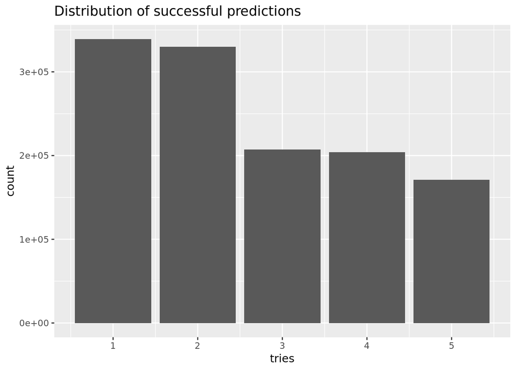

```r
# distribution of successful cases
p <- ggplot(data=success, aes(x=tries, y=count)) + geom_bar(stat="identity") + ggtitle("Distribution of successful predictions")
p
```

## Current milestone status

At this stage the following steps have been completed:

- The model training framework is operational
- The testing framework as well
- The model is significantly better than random, but not yet adequate